# 210226_glm-linkersvsnucs_kvdb

Koen Van den Berge

4/7/2021

```r
data <- read.table("../data/combined.txt", header = TRUE)
```

# EDA

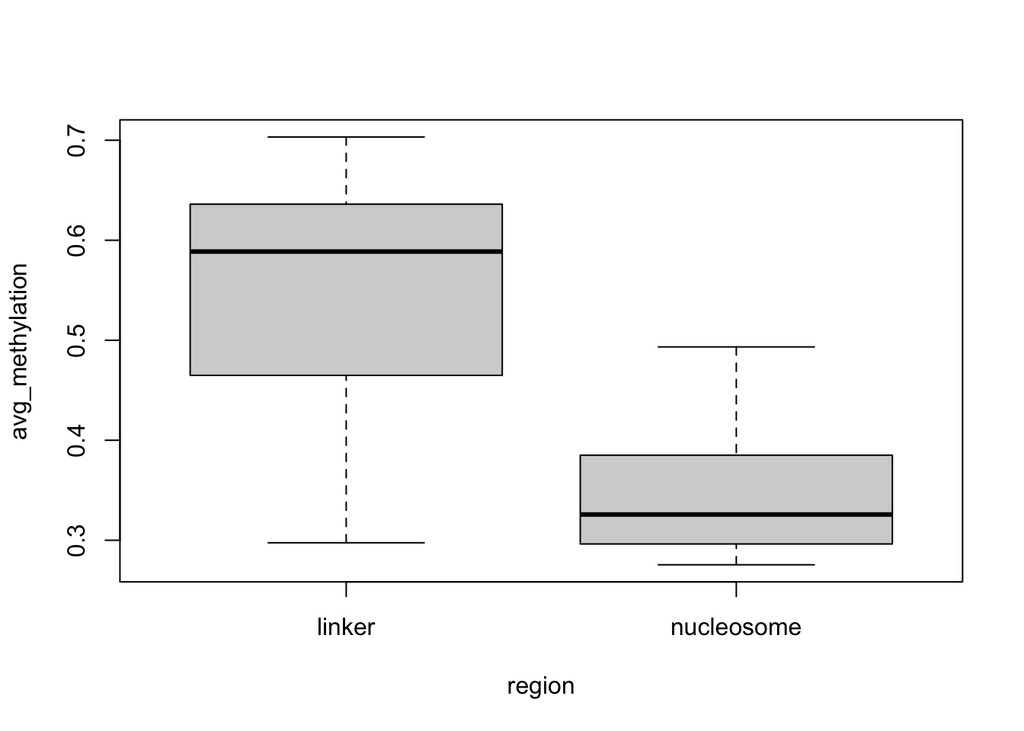

```r
boxplot(avg_methylation ~ region, data = data)
```

# Fit a Binomial model

Below we’re fitting a Binomial GLM. Note that, while the Binomial GLM does not find a significant difference in average methylation between the nucleosome and linker regions, the visualization above clearly shows there actually is quite a large difference. This is because the data does not conform to the Binomial distribuition. In particular, the variability in the data is lower than what is assumed by a Binomial distribution. This causes standard errors to be larger than they should be, hence inflating p-values.

```r
m <- glm(avg_methylation ~ region,
         data = data,
         family = "binomial")
summary(m)
```

```
##
## Call:
## glm(formula = avg_methylation ~ region, family = "binomial",
##     data = data)
##
## Deviance Residuals:
##      Min        1Q    Median        3Q       Max
## -0.49852  -0.12711  -0.01953   0.16511   0.32542
##
## Coefficients:
##                  Estimate Std. Error z value Pr(>|z|)
## (Intercept)        0.1774     0.6054   0.293    0.770
## regionnucleosome  -0.7798     0.8742  -0.892    0.372
##
## (Dispersion parameter for binomial family taken to be 1)
##
##     Null deviance: 1.8484  on 21  degrees of freedom
## Residual deviance: 1.0370  on 20  degrees of freedom
## AIC: 28.409
##
## Number of Fisher Scoring iterations: 3
```

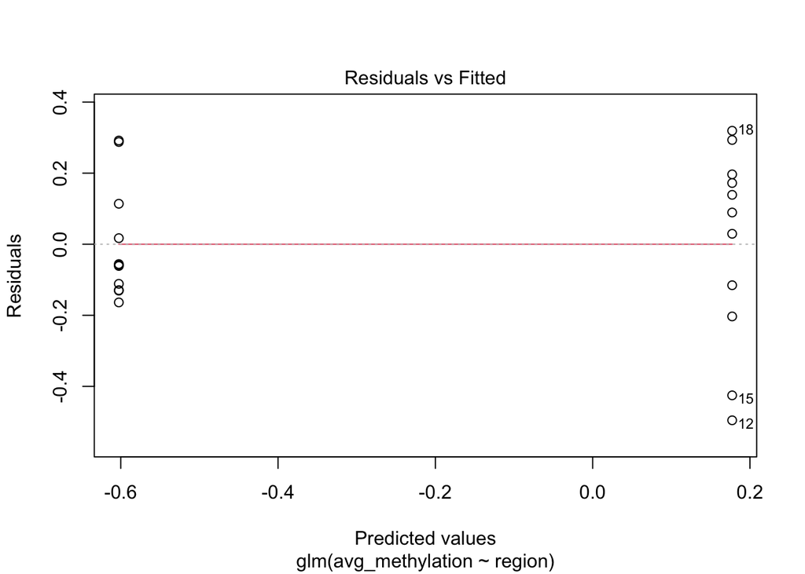

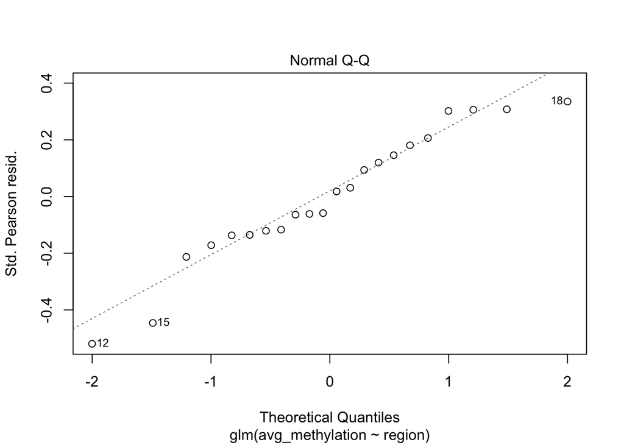

```
## hat values (leverages) are all = 0.09090909
##  and there are no factor predictors; no plot no. 5
```

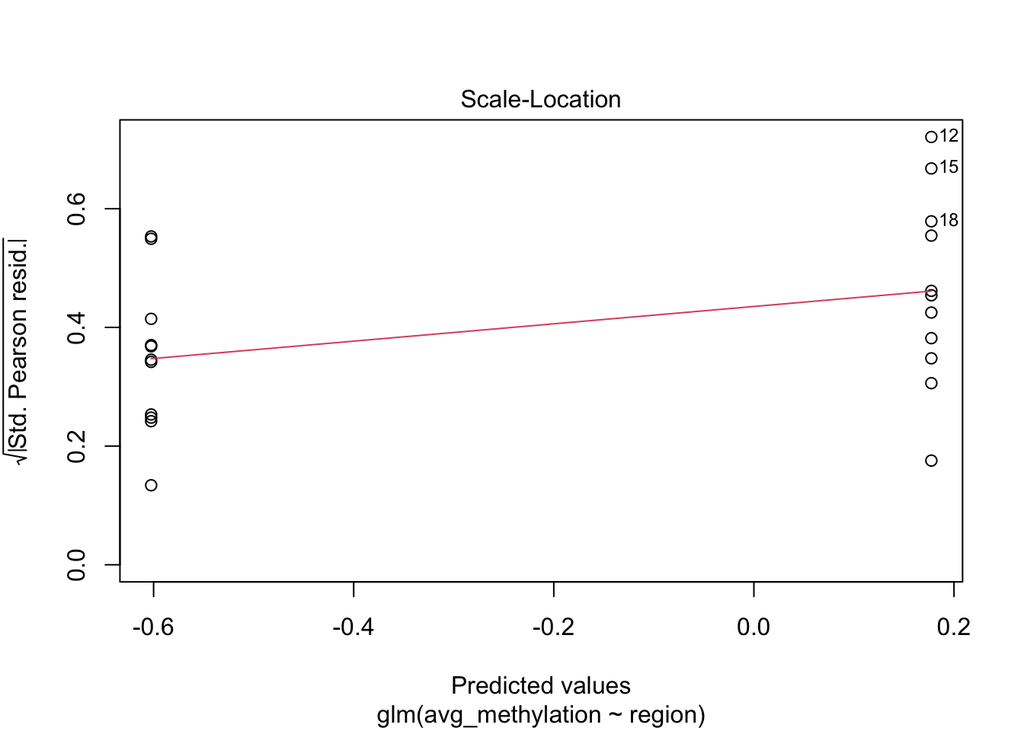

```r
plot(m)
```

# Checking for overdispersion by estimating a dispersion parameter.

Let $Y_i$ be the average methylation in bin $i$, and $x_i$ the binary covariate defining whether bin $i$ is a linker or nucleosome region. The Binomial GLM can then be defined as

$$\left\{
\begin{array}{ccc}
Y_i & \sim & B(\pi_i)\\
\log \left( \frac{\pi_i}{1-\pi_i} \right) & = & \eta_i\\
\eta_i & = & \beta_0 + \beta_1 x_{1i}
\end{array}\right.$$

Let $\hat{\beta}_0$ and $\hat{\beta}_1$ be the estimates for $\beta_0$ and $\beta_1$, respectively, after fitting the Binomial GLM. Then, we can define Pearson residuals as

$$e_i = \frac{Y_i - \hat{\mu}_i}{Var(\hat{\mu}_i)}.$$

Theory tells us that, if the Binomial GLM holds, we can expect

$$e_i \sim N(0, 1),$$

i.e. the Pearson residuals follow a standard normal distribution. Note that, assuming the standard normal distribution, their variance would be

$$Var(e_i) = \frac{1}{n-p} \sum_i \left\{ (e_i - \bar{e}_i)^2\right\} = \frac{1}{n-p} \sum_i e_i^2.$$

The right hand side holds because, the mean residual $\bar{e}_i$ equals zero by definition. Note that we divide by $n-p$ and not by $n$ because this is an unbiased estimate of the variance (i.e., we need to account for the $p$ parameters estimated in the GLM). This is analogous to dividing by $n-1$, rather than by $n$, in the usual variance estimate of a random variable to account for estimating its mean.

If the model assumptions hold, therefore, we would expect that

$$\frac{1}{n-p} \sum_i e_i^2 = 1.$$

Let’s set set $\phi = \frac{1}{n-p} \sum_i e_i^2$. Then, $\phi$ is something we’re calling an dispersion parameter; or in some cases a scale parameter. Below we estimate such an dispersion parameter. The dispersion parameter should be around 1 (roughly in [0.8, 1.2]) if the data reasonably well conforms to the Binomial. Here, it is **much** lower than 1, hence we’re dealing with data that is underdispersed with respect to the Binomial distribution.

```r
epsilon <- resid(m, type="pearson")
n  <- nrow(data) # number of data points
p  <- length(coef(m))  # number of coefficients
disp <- sum(epsilon^2) / (n - p) # dispersion estimate
disp # if the variance would conform a Binomial this should be around 1. underdispersion
```

```
## [1] 0.05148557
```

# Fit a quasibinomial GLM

Note how the dispersion parameter estimated by the GLM function is practically the same as the one we’ve derived above. The p-value now is much lower, because we’re fitting a quasibinomial model, which allows the assumed variance to adept based on the data at hand.

```r
m <- glm(avg_methylation ~ region,
         data = data,
         family = "quasibinomial")
summary(m)
```

```
##
## Call:
## glm(formula = avg_methylation ~ region, family = "quasibinomial",
##     data = data)
##
## Deviance Residuals:
##      Min        1Q    Median        3Q       Max
## -0.49852  -0.12711  -0.01953   0.16511   0.32542
##
## Coefficients:
##                  Estimate Std. Error t value Pr(>|t|)
## (Intercept)        0.1774     0.1374   1.291 0.211377
## regionnucleosome  -0.7798     0.1983  -3.931 0.000826 ***
## ---
## Signif. codes:  0 '***' 0.001 '**' 0.01 '*' 0.05 '.' 0.1 ' ' 1
##
## (Dispersion parameter for quasibinomial family taken to be 0.05148561)
##
##     Null deviance: 1.8484  on 21  degrees of freedom
## Residual deviance: 1.0370  on 20  degrees of freedom
## AIC: NA
##
## Number of Fisher Scoring iterations: 3
```

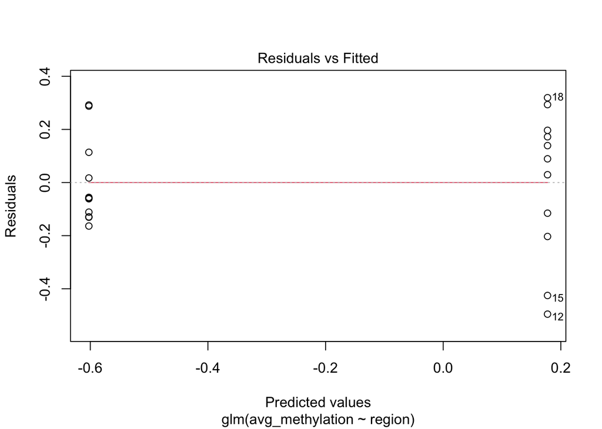

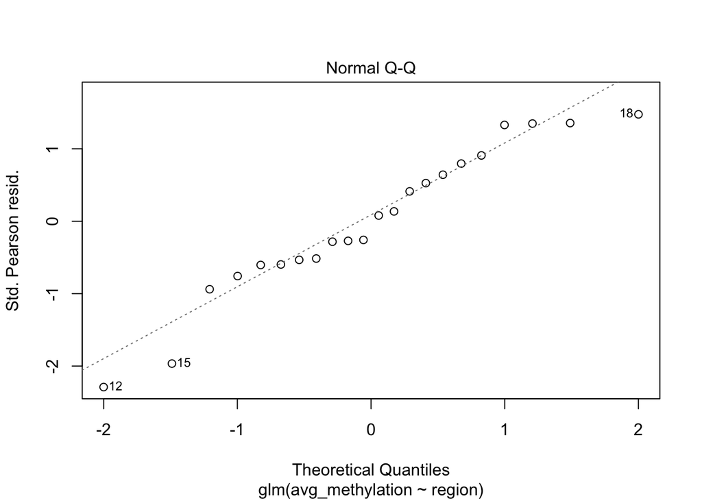

```
## hat values (leverages) are all = 0.09090909
##  and there are no factor predictors; no plot no. 5
```

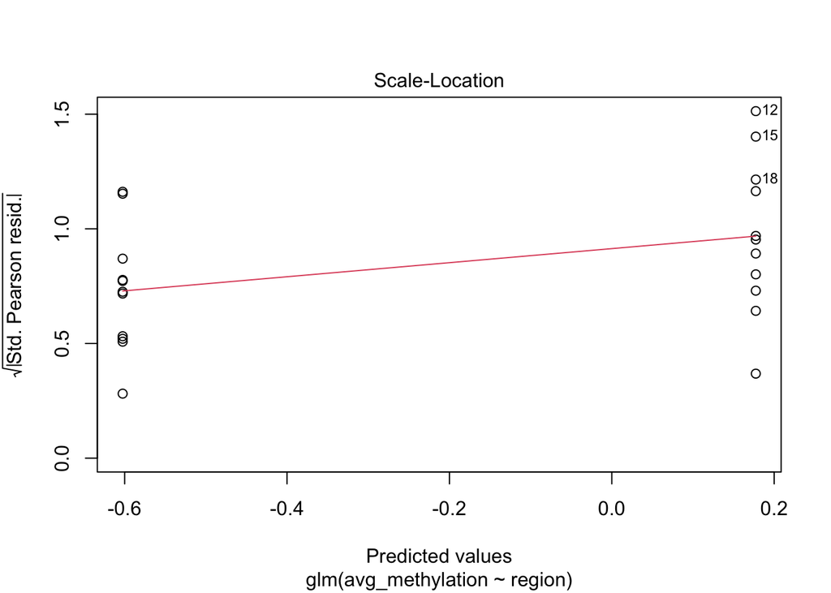

```r
plot(m)
```